# Phylogenetics: Theory and Overview

## The KL divergence contains the AIC

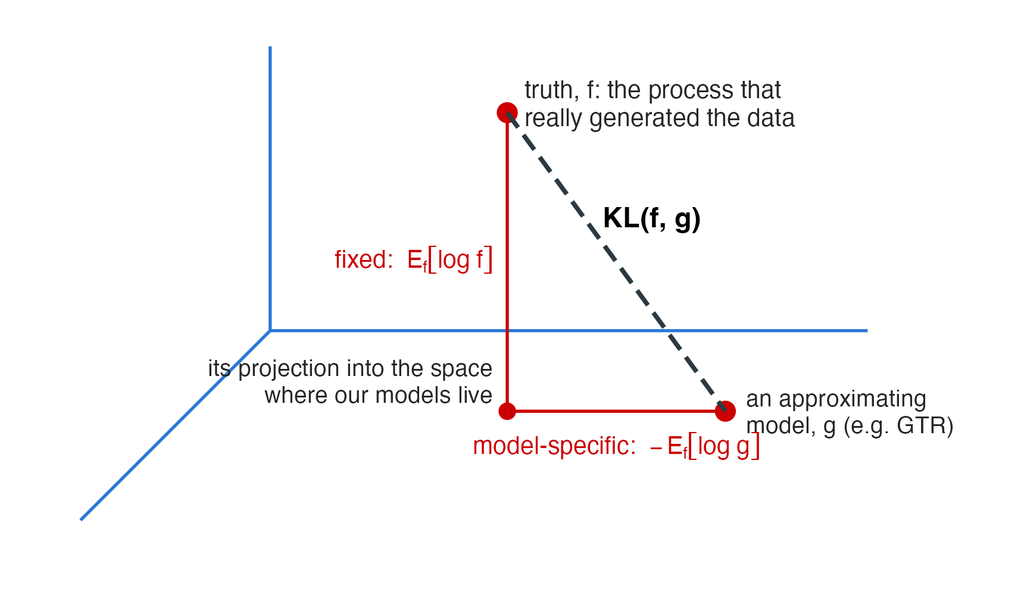

$$\begin{aligned}
\mathrm{KL}(f,g) &= \int f(x)\log\frac{f(x)}{g(x)}\,dx\\[4pt]
&= \underbrace{E_f[\log f]}_{\text{same for every model}} - \underbrace{E_f[\log g]}_{\text{model-specific}}
\end{aligned}$$

AIC estimates the model-specific part (times $-2$), corrected for the bias of using the same data to fit $g$.

## Several candidate models

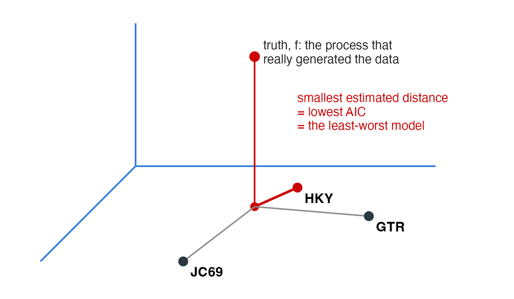

AIC estimates each model’s distance from the truth, up to a constant shared by all of them.

## Comparing candidate models: a baobab gene

ModelFinder on one 1,950 bp nuclear gene from the baobab data (18 sequences):

| Model | $k$ | $\log \hat L$ | AIC | $\Delta$AIC | $\Delta$BIC |
| --- | --- | --- | --- | --- | --- |
| JC69 | 33 | −4221.76 | 8509.52 | 214.48 | 186.60 |
| JC69+Γ | 34 | −4206.20 | 8480.40 | 185.35 | 163.05 |
| K80 | 34 | −4157.71 | 8383.43 | 88.38 | 66.08 |
| K80+Γ | 35 | −4141.26 | 8352.52 | 57.47 | 40.75 |
| HKY85 | 37 | −4125.81 | 8325.63 | 30.58 | 25.00 |
| **HKY85+Γ** | **38** | **−4109.52** | **8295.05** | **0** | **0** |
| GTR | 41 | −4123.40 | 8328.79 | 33.75 | 50.47 |
| GTR+Γ | 42 | −4106.94 | 8297.88 | 2.83 | 25.13 |

## Alternatives to AIC

$$\mathrm{AIC_c} = 2k - 2\log\hat L + \frac{2k^2 + 2k}{N - k - 1}
\qquad\qquad
\mathrm{BIC} = k\log N - 2\log\hat L$$

- **AICc** corrects for small sample size $N$ (alignment length).
- **BIC** penalizes parameters more heavily as $N$ grows (Schwarz 1978).
- There’s no consensus on which is best; programs report all three. ModelFinder uses BIC by default.

# ML in practice

## Many loci, one analysis

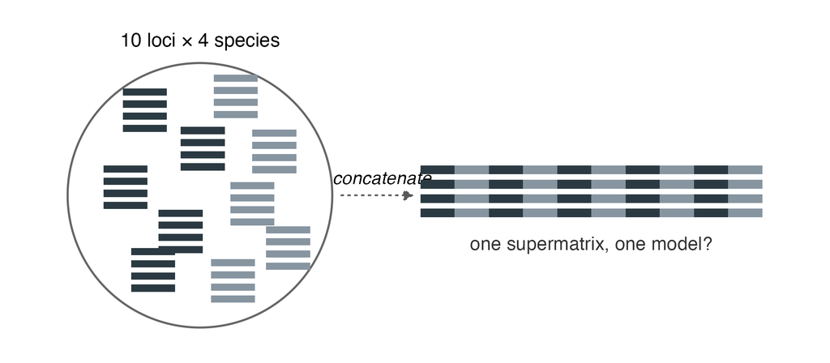

If you can analyze one locus well, you can analyze a hundred — usually by **concatenating** them into one supermatrix.

## Should each gene have its own model?

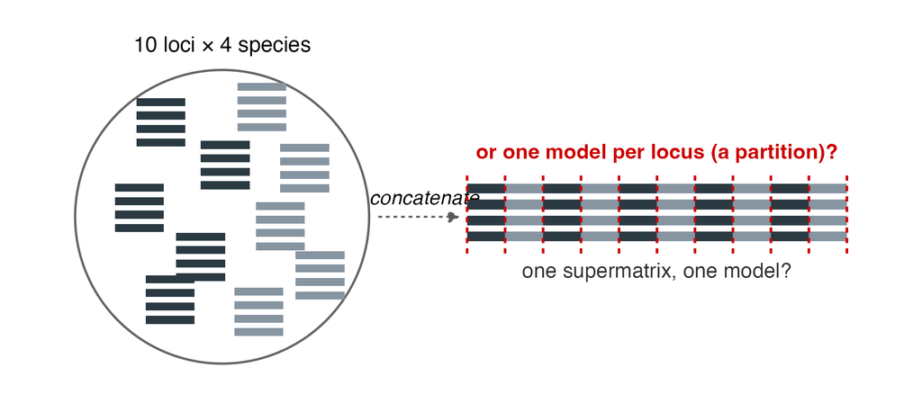

**Partitioned** analyses give each block its own $Q$, rate variation and/or relative rate. Concatenated ML with partitioned mixture models is in almost every phylogenomics paper.

## Same data, different models, different trees

What is sister to all other flowering plants? Disagreement between the **slowly evolving** sites and **fast** sites (Xi et al. 2014).

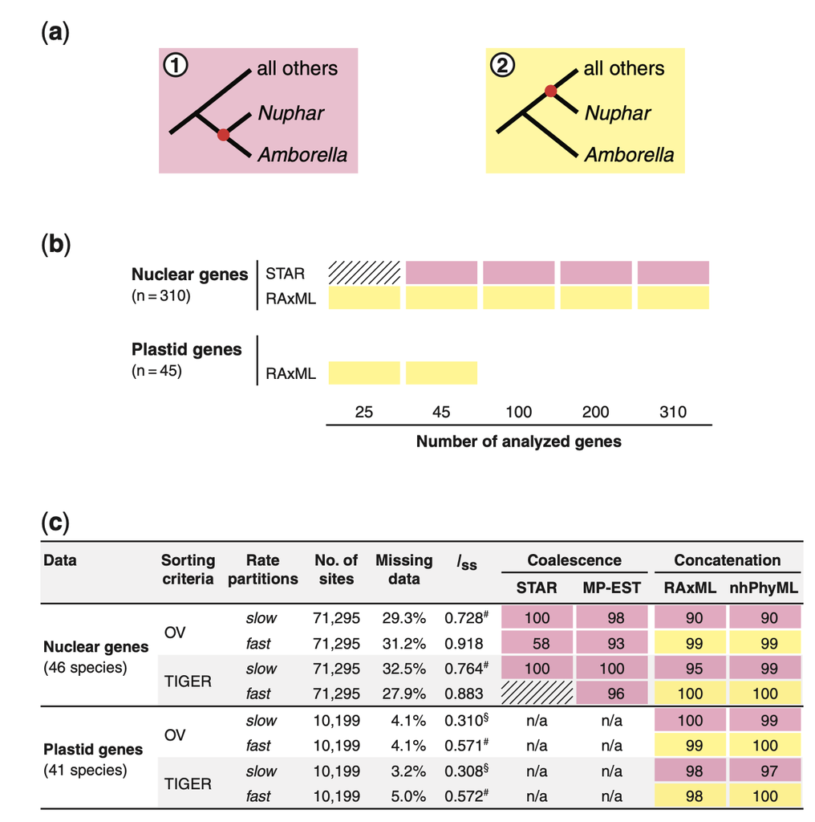

Conflicting evidence for early angiosperm evolution based on partitioning strategies and model choice. Fig. 1 from Xi et al. (2014)

The Amborella genome paper (Amborella Genome Project 2013) has Amborella alone as sister to all other angiosperms, the more accepted hypothesis.

## Target capture: conserved exons, variable flanks

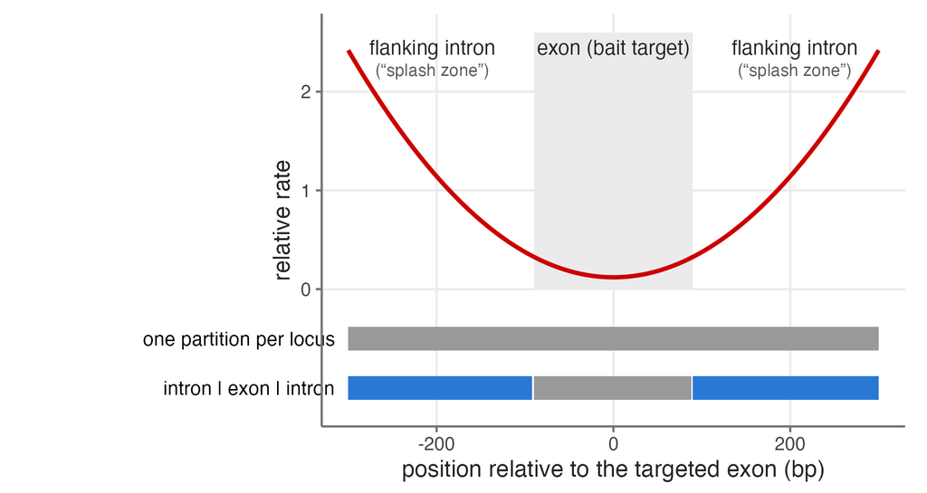

Plant phylogenomics mostly uses **target capture** (Hyb-Seq): baits for low-copy exons, plus the flanking introns that come along with them (Weitemier et al. 2014; Johnson et al. 2016).

- **Angiosperms353**: one bait set for any flowering plant (Johnson et al. 2019).
- The baobab genes are Hyb-Seq data too (Karimi et al. 2020).
- Exons are slow and introns fast, so partition them separately, as for UCEs (Tagliacollo and Lanfear 2018).

## Data-driven partitioning and model selection

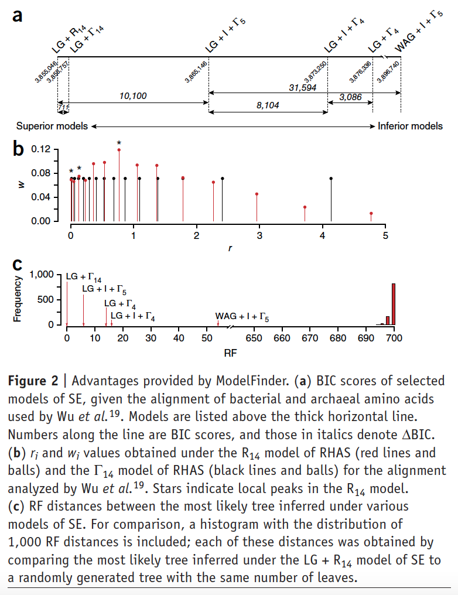

**ModelFinder** searches substitution models, $+\Gamma$ / $+I$ / free-rate, *and* partitioning schemes, and returns the best by BIC (Kalyaanamoorthy et al. 2017).

**IQ-TREE 2** (Minh et al. 2020):

- fast, with model selection built in;
- well-annotated log files;
- many conveniences for many loci;
- most often returns the highest likelihood in benchmarks.

## Support for ML trees: the bootstrap

- Resample alignment columns **with replacement**, re-estimate the tree, repeat 100–1000×.
- **Bootstrap support** for a clade = the fraction of replicate trees that contain it (Felsenstein 1985).
- It measures how **consistently the data** point to a clade, *given the model*. It is not the probability that the clade is true.

# Key takeaways

## Summary

- A phylogeny is a **model-based hypothesis**.
- **Neighbor-joining**: a distance-based method that is fast and works well when divergence is not too high. It often gives a reasonable starting tree.
- **Likelihood**: considers the uncertainty in the unobserved states.
- **Models**: JC69 ⊂ HKY ⊂ GTR, plus $+\Gamma$ / partitions. An example was for a single baobab gene, HKY85+Γ wins on AIC and BIC. This could lead to different branch lengths and potentially a different gene tree.
- Confidence intervals can be placed on ML trees using **bootstrapping**.

# References

Akaike, Hirotugu. 1974. “A New Look at the Statistical Model Identification.” *IEEE Transactions on Automatic Control* 19 (6): 716–23. https://doi.org/10.1109/TAC.1974.1100705.

Amborella Genome Project. 2013. “The Amborella Genome and the Evolution of Flowering Plants.” *Science* 342 (6165): 1241089. https://doi.org/10.1126/science.1241089.

Chase, Mark W., Douglas E. Soltis, Richard G. Olmstead, et al. 1993. “Phylogenetics of Seed Plants: An Analysis of Nucleotide Sequences from the Plastid Gene rbcL.” *Annals of the Missouri Botanical Garden* 80 (3): 528–80. https://doi.org/10.2307/2399846.

Felsenstein, Joseph. 1981. “Evolutionary Trees from DNA Sequences: A Maximum Likelihood Approach.” *Journal of Molecular Evolution* 17 (6): 368–76. https://doi.org/10.1007/BF01734359.

———. 1985. “Confidence Limits on Phylogenies: An Approach Using the Bootstrap.” *Evolution* 39 (4): 783–91. https://doi.org/10.1111/j.1558-5646.1985.tb00420.x.

Grass Phylogeny Working Group II. 2012. “New Grass Phylogeny Resolves Deep Evolutionary Relationships and Discovers C4 Origins.” *New Phytologist* 193 (2): 304–12. https://doi.org/10.1111/j.1469-8137.2011.03972.x.

Hasegawa, Masami, Hirohisa Kishino, and Taka-aki Yano. 1985. “Dating of the Human-Ape Splitting by a Molecular Clock of Mitochondrial DNA.” *Journal of Molecular Evolution* 22 (2): 160–74. https://doi.org/10.1007/BF02101694.

Johnson, Matthew G., Elliot M. Gardner, Yang Liu, et al. 2016. “HybPiper: Extracting Coding Sequence and Introns for Phylogenetics from High-Throughput Sequencing Reads Using Target Enrichment.” *Applications in Plant Sciences* 4 (7): 1600016. https://doi.org/10.3732/apps.1600016.

Johnson, Matthew G., Lisa Pokorny, Steven Dodsworth, et al. 2019. “A Universal Probe Set for Targeted Sequencing of 353 Nuclear Genes from Any Flowering Plant Designed Using k-Medoids Clustering.” *Systematic Biology* 68 (4): 594–606. https://doi.org/10.1093/sysbio/syy086.

Jukes, Thomas H., and Charles R. Cantor. 1969. “Evolution of Protein Molecules.” In *Mammalian Protein Metabolism*, edited by Hamish N. Munro, 21–132. New York: Academic Press. https://doi.org/10.1016/B978-1-4832-3211-9.50009-7.

Kalyaanamoorthy, Subha, Bui Quang Minh, Thomas K. F. Wong, Arndt von Haeseler, and Lars S. Jermiin. 2017. “ModelFinder: Fast Model Selection for Accurate Phylogenetic Estimates.” *Nature Methods* 14 (6): 587–89. https://doi.org/10.1038/nmeth.4285.

Kapralov, Maxim V., and Dmitry A. Filatov. 2007. “Widespread Positive Selection in the Photosynthetic Rubisco Enzyme.” *BMC Evolutionary Biology* 7 (1): 73. https://doi.org/10.1186/1471-2148-7-73.

Karimi, Nisa, Corrinne E. Grover, Joseph P. Gallagher, Jonathan F. Wendel, Cécile Ané, and David A. Baum. 2020. “Reticulate Evolution Helps Explain Apparent Homoplasy in Floral Biology and Pollination in Baobabs (Adansonia; Bombacoideae; Malvaceae).” *Systematic Biology* 69 (3): 462–78. https://doi.org/10.1093/sysbio/syz073.

Magallón, Susana, Sandra Gómez-Acevedo, Luna L. Sánchez-Reyes, and Tania Hernández-Hernández. 2015. “A Metacalibrated Time-Tree Documents the Early Rise of Flowering Plant Phylogenetic Diversity.” *New Phytologist* 207 (2): 437–53. https://doi.org/10.1111/nph.13264.

Minh, Bui Quang, Heiko A. Schmidt, Olga Chernomor, et al. 2020. “IQ-TREE 2: New Models and Efficient Methods for Phylogenetic Inference in the Genomic Era.” *Molecular Biology and Evolution* 37 (5): 1530–34. https://doi.org/10.1093/molbev/msaa015.

Schwarz, Gideon. 1978. “Estimating the Dimension of a Model.” *The Annals of Statistics* 6 (2): 461–64. https://doi.org/10.1214/aos/1176344136.

Tagliacollo, Victor A., and Robert Lanfear. 2018. “Estimating Improved Partitioning Schemes for Ultraconserved Elements.” *Molecular Biology and Evolution* 35 (7): 1798–1811. https://doi.org/10.1093/molbev/msy069.

Tavaré, Simon. 1986. “Some Probabilistic and Statistical Problems in the Analysis of DNA Sequences.” *Lectures on Mathematics in the Life Sciences* 17: 57–86.

The Angiosperm Phylogeny Group. 2016. “An Update of the Angiosperm Phylogeny Group Classification for the Orders and Families of Flowering Plants: APG IV.” *Botanical Journal of the Linnean Society* 181 (1): 1–20. https://doi.org/10.1111/boj.12385.

Weitemier, Kevin, Shannon C. K. Straub, Richard C. Cronn, et al. 2014. “Hyb-Seq: Combining Target Enrichment and Genome Skimming for Plant Phylogenomics.” *Applications in Plant Sciences* 2 (9): 1400042. https://doi.org/10.3732/apps.1400042.

Xi, Zhenxiang, Liang Liu, Joshua S. Rest, and Charles C. Davis. 2014. “Coalescent Versus Concatenation Methods and the Placement of Amborella as Sister to Water Lilies.” *Systematic Biology* 63 (6): 919–32. https://doi.org/10.1093/sysbio/syu055.

Yang, Ziheng. 1994. “Maximum Likelihood Phylogenetic Estimation from DNA Sequences with Variable Rates over Sites: Approximate Methods.” *Journal of Molecular Evolution* 39 (3): 306–14. https://doi.org/10.1007/BF00160154.

———. 1995. “A Space-Time Process Model for the Evolution of DNA Sequences.” *Genetics* 139 (2): 993–1005. https://doi.org/10.1093/genetics/139.2.993.